# homework_4_vo_ken

Ken Vo

February 26, 2019

```r
library(tidyverse)
library(mdsr)
library(nycflights13)
```

—————————————–SECTION 5.6 EXERCISES————————————-

Exercise 5.6.7-#2 answer:

```r
flights %>%
  filter (!is.na(dep_delay), !is.na(arr_delay)) %>%
  group_by(dest) %>%
  summarize(n=n())
```

```
## # A tibble: 104 x 2
##    dest      n
##    <chr> <int>
##  1 ABQ     254
##  2 ACK     264
##  3 ALB     418
##  4 ANC       8
##  5 ATL   16837
##  6 AUS    2411
##  7 AVL     261
##  8 BDL     412
##  9 BGR     358
## 10 BHM     269
## # … with 94 more rows
```

```r
flights %>%
  filter (!is.na(dep_delay), !is.na(arr_delay)) %>%
  group_by(tailnum) %>%
  tally(wt=distance)
```

```
## # A tibble: 4,037 x 2
##    tailnum      n
##    <chr>    <dbl>
##  1 D942DN    3418
##  2 N0EGMQ  239143
##  3 N10156  109664
##  4 N102UW   25722
##  5 N103US   24619
##  6 N104UW   24616
##  7 N10575  139903
##  8 N105UW   23618
##  9 N107US   21677
## 10 N108UW   32070
## # … with 4,027 more rows
```

Exercise 5.6.7-#4 answer:

There is a pattern in the cancelled flights. The proportion of cancelled flights is related to the average delay. The higher the average delay of the day, the higher the proportion of cancelled flights.

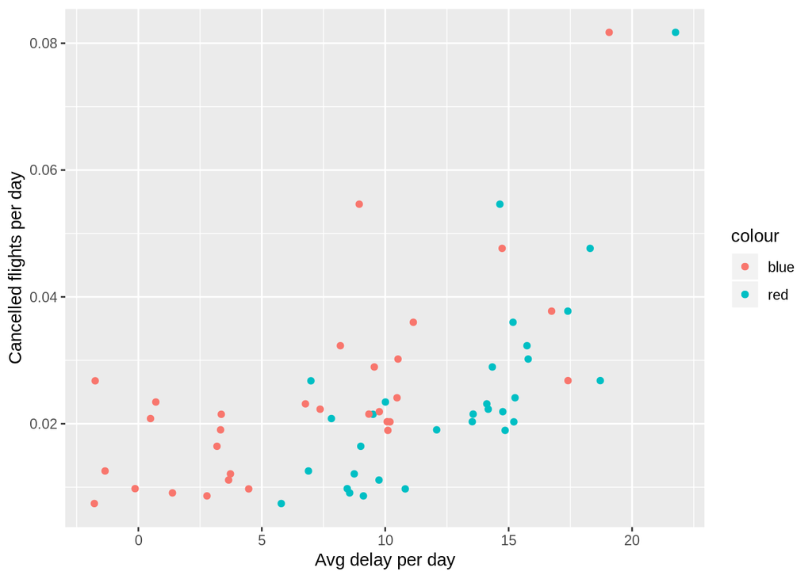

```r
flights %>%
  group_by(day) %>%
  summarize(cancelled=mean(is.na(dep_delay)),
            mean_dep=mean(dep_delay, na.rm=T),
            mean_arr=mean(arr_delay, na.rm=T)) %>%
  ggplot(aes(y=cancelled))+
  geom_point(aes(x=mean_dep, color='red'))+
  geom_point(aes(x=mean_arr, color='blue'))+
  labs(x="Avg delay per day", y="Cancelled flights per day")
```

Exercise 5.6.7-#6 answer: The sort arguement will sort the results of count() in descending order. This could be use to arrange the results after completing the count.

—————————————SECTION 10 EXERCISES—————————————-

```r
print(mtcars)
```

```
##                      mpg cyl  disp  hp drat    wt  qsec vs am gear carb
## Mazda RX4           21.0   6 160.0 110 3.90 2.620 16.46  0  1    4    4
## Mazda RX4 Wag       21.0   6 160.0 110 3.90 2.875 17.02  0  1    4    4
## Datsun 710          22.8   4 108.0  93 3.85 2.320 18.61  1  1    4    1
## Hornet 4 Drive      21.4   6 258.0 110 3.08 3.215 19.44  1  0    3    1
## Hornet Sportabout   18.7   8 360.0 175 3.15 3.440 17.02  0  0    3    2
## Valiant             18.1   6 225.0 105 2.76 3.460 20.22  1  0    3    1
## Duster 360          14.3   8 360.0 245 3.21 3.570 15.84  0  0    3    4
## Merc 240D           24.4   4 146.7  62 3.69 3.190 20.00  1  0    4    2
## Merc 230            22.8   4 140.8  95 3.92 3.150 22.90  1  0    4    2
## Merc 280            19.2   6 167.6 123 3.92 3.440 18.30  1  0    4    4
## Merc 280C           17.8   6 167.6 123 3.92 3.440 18.90  1  0    4    4
## Merc 450SE          16.4   8 275.8 180 3.07 4.070 17.40  0  0    3    3
## Merc 450SL          17.3   8 275.8 180 3.07 3.730 17.60  0  0    3    3
## Merc 450SLC         15.2   8 275.8 180 3.07 3.780 18.00  0  0    3    3
## Cadillac Fleetwood  10.4   8 472.0 205 2.93 5.250 17.98  0  0    3    4
## Lincoln Continental 10.4   8 460.0 215 3.00 5.424 17.82  0  0    3    4
## Chrysler Imperial   14.7   8 440.0 230 3.23 5.345 17.42  0  0    3    4
## Fiat 128            32.4   4  78.7  66 4.08 2.200 19.47  1  1    4    1
## Honda Civic         30.4   4  75.7  52 4.93 1.615 18.52  1  1    4    2
## Toyota Corolla      33.9   4  71.1  65 4.22 1.835 19.90  1  1    4    1
## Toyota Corona       21.5   4 120.1  97 3.70 2.465 20.01  1  0    3    1
## Dodge Challenger    15.5   8 318.0 150 2.76 3.520 16.87  0  0    3    2
## AMC Javelin         15.2   8 304.0 150 3.15 3.435 17.30  0  0    3    2
## Camaro Z28          13.3   8 350.0 245 3.73 3.840 15.41  0  0    3    4
## Pontiac Firebird    19.2   8 400.0 175 3.08 3.845 17.05  0  0    3    2
## Fiat X1-9           27.3   4  79.0  66 4.08 1.935 18.90  1  1    4    1
## Porsche 914-2       26.0   4 120.3  91 4.43 2.140 16.70  0  1    5    2
## Lotus Europa        30.4   4  95.1 113 3.77 1.513 16.90  1  1    5    2
## Ford Pantera L      15.8   8 351.0 264 4.22 3.170 14.50  0  1    5    4
## Ferrari Dino        19.7   6 145.0 175 3.62 2.770 15.50  0  1    5    6
## Maserati Bora       15.0   8 301.0 335 3.54 3.570 14.60  0  1    5    8
## Volvo 142E          21.4   4 121.0 109 4.11 2.780 18.60  1  1    4    2
```

Exercise 10.5-#1 answer: If an object is a tibble, the print command prints only the first 10 observations (rows) and all the columns that can be fitted on the screen.

Exercise 10.5-#2 answer: When using $ in df$x when the object is a data.frames, the $ option would complete the column heading of xyz and returns a value - i.e. we don’t need to type out “xyz” when we are requesting value for that colmn. When the object is tibble, the $ option would not complete the column heading and specifically look for a column that is specified by whatever that comes after $.

With data.frames, with `[` the type of object that is returned differs on the number of columns. If it is one column, it won’t return a data.frame, but instead will return a vector. With more than one column, then it will return a data.frame.

```r
df <- data.frame(abc=1, xyz="a")
df$x
```

```
## [1] a
## Levels: a
```

```r
df[, "xyz"]
```

```
## [1] a
## Levels: a
```

```r
df[,c("abc", "xyz")]
```

```
##   abc xyz
## 1   1   a
```

```r
tbl <- as_tibble(df)
tbl$x
```

[output not shown]

```r
tbl[, "xyz"]
```

```
## # A tibble: 1 x 1
##   xyz
##   <fct>
## 1 a
```

```r
tbl[,c("abc", "xyz")]
```

```
## # A tibble: 1 x 2
##     abc xyz
##   <dbl> <fct>
## 1     1 a
```

Exercise 10.5-#3 answer: One can use the double bracket to extract the reference variable from a tibble.

Exercise 10.5-#6 answer: The help page for the print method of the tibble object. The n-extra arguement determines the number of extra columns to print information for the tible.

————————————SECTION 12.3 EXERCISES—————————————–

Exercise 12.3.3-#3 answer: Spreading this data frame fails because the name and key columns do not uniquely identify rows. Specifically, there are two rows with values for the age of “Phillip Woods”

One could add a column that has distinctive value for the same rows.

Exercise 12.3.3-#4 answer: To tidy the preg tibble, we need to use gather(). The variables in this data are: sex, pregnant and count.

```r
preg <- tribble(
  ~pregnant, ~male, ~female,
  "yes", NA, 10,
  "no", 20, 12
)

preg_tidy <- preg %>%
  gather(male, female, key="sex", value="count")

preg_tidy
```

```
## # A tibble: 4 x 3
##   pregnant sex    count
##   <chr>    <chr>  <dbl>
## 1 yes      male      NA
## 2 no       male      20
## 3 yes      female    10
## 4 no       female    12
```

————————————–SECTION 12.4 EXERCISES——————————————-

Exercise 12.4.3-#1 answer: The extra argument tells separate() what to do if there are too many pieces, and teh fill argument tells it what to do if there aren’t enough.

```r
tibble(x=c("a,b,c","d,e,f,g","h,i,j")) %>%
  separate(x, c("one", "two", "three"))
```

```
## # A tibble: 3 x 3
##   one   two   three
##   <chr> <chr> <chr>
## 1 a     b     c
## 2 d     e     f
## 3 h     i     j
```

```r
# using drop extra
tibble(x=c("a,b,c","d,e,f,g","h,i,j")) %>%
  separate(x, c("one", "two", "three", extra="drop"))
```

```
## # A tibble: 3 x 4
##   one   two   three drop
##   <chr> <chr> <chr> <chr>
## 1 a     b     c     <NA>
## 2 d     e     f     g
## 3 h     i     j     <NA>
```

```r
# using merge extra causing the extra value to merge
tibble(x=c("a,b,c","d,e,f,g","h,i,j")) %>%
  separate(x, c("one", "two", "three", extra="merge"))
```

```
## # A tibble: 3 x 4
##   one   two   three merge
##   <chr> <chr> <chr> <chr>
## 1 a     b     c     <NA>
## 2 d     e     f     g
## 3 h     i     j     <NA>
```

Exercise 12.4.3-#2 answer: The remove argument would delete input columns in the result data frame.

———————————–EXTRA—————————————-

```r
file_path <- "/home/me/Downloads/baby_names.txt"
baby_names <- read_csv(file=file_path)
glimpse(baby_names)
```

```
## Observations: 30,000
## Variables: 1
## $ `year|sex|name|n|prop` <chr> "1880|F|Mary|7065|0.0723843285111266", "1…
```

```r
write.csv(baby_names, file = "baby_names.csv")


file_path <- "/home/me/Documents/Data Science Certificate Courses/Compscix-415-2/compscix-415-2-assignements/baby_names.csv"
baby_names_csv <- read_csv(file=file_path)
glimpse(baby_names_csv)
```

```
## Observations: 30,000
## Variables: 2
## $ X1                     <dbl> 1, 2, 3, 4, 5, 6, 7, 8, 9, 10, 11, 12, 13…
## $ `year|sex|name|n|prop` <chr> "1880|F|Mary|7065|0.0723843285111266", "1…
```